# Plot analysis on Jane Austen’s books

In this notebook, we will use sentiment analysis to analyze some of English writer Jane Austen’s most famous books. Specifically, we will try to get information on how the plot progresses throughout the chapters in these stories.

First of all, let’s import some essential libraries.

```r
library(dplyr)  # gives you the '%>%' operator among many other useful things
library(ggplot2)
```

To achieve our task, we will use the dataset provided in the *janeaustenr* R library.

```r
library(janeaustenr)  # we will get our dataset from here. Make sure you install the package before!

austen <- austen_books()  # store an instance of the dataset in our variable `austen`
head(austen, 10)  # display 10 top rows in austen.
```

```
## # A tibble: 10 x 2
##    text                  book
##    <chr>                 <fct>
##  1 SENSE AND SENSIBILITY Sense & Sensibility
##  2 ""                    Sense & Sensibility
##  3 by Jane Austen        Sense & Sensibility
##  4 ""                    Sense & Sensibility
##  5 (1811)                Sense & Sensibility
##  6 ""                    Sense & Sensibility
##  7 ""                    Sense & Sensibility
##  8 ""                    Sense & Sensibility
##  9 ""                    Sense & Sensibility
## 10 CHAPTER 1             Sense & Sensibility
```

The table *austen* contains two columns:

- *text*: a piece of text representing a line in the book.
- *book*: the book the piece of text was taken from.

The text in this data is tokenized by line. Note the difference between line and sentence. A line is a horizontal unit of text that spans from left to right in a book. A sentence is set of words that are complete in themselves, that convey some thought. A line might well cut a sentence in the middle. Furthermore, a line is highly-dependent on the size of the book: lines in a wider book will hold more words. This line tokenization will not allow us to do any analysis on the meaning conveyed in the stories. Therefore, we will have to think of something else …

## Exploring the dataset

First, let’s find which books are present in the dataset.

```r
austen %>% distinct(book)
```

```
## # A tibble: 6 x 1
##   book
##   <fct>
## 1 Sense & Sensibility
## 2 Pride & Prejudice
## 3 Mansfield Park
## 4 Emma
## 5 Northanger Abbey
## 6 Persuasion
```

Let’s plot the number of lines we have for each book. For this, we will use a bar plot.

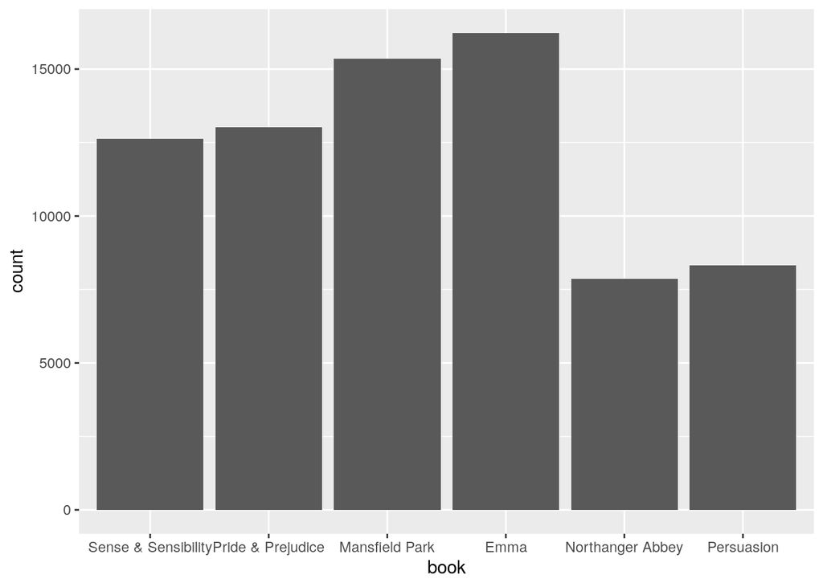

```r
# Because we are using geom_bar(), the count of rows belonging to each book is implicitly set as the y-axis
ggplot(austen, aes(x=book)) + geom_bar()
```

We notice that the highest number of lines in our dataset belongs to ‘Emma’. In the next section, we will try to tokenize Emma into chapters.